# Noções básicas de linguagem R aplicadas à biologia aquática

### **Pacotes usados no minicurso**

```r
# Pacotes------------------------------------------------

library(tidyverse)
library(readxl)
library(ggtext)
library(ggthemes)
library(broom)
library(patchwork)
library(rstatix)
library(car)
library(devtools)
```

### **Leitura dos dados**

```r
# Leitura dos dados ------------------------------------

# Função read_xlsx do pacote readxl

# Lendo dados pelo Ctrl C + Ctrl V
#dados_ictio <- read.delim2(file = "clipboard", header = TRUE)

# Lendo dados de arquivos .csv
#dados_ictio <- read.csv2("dados/dados_esp.csv")
#dados_ictio

# Lendo dados de arquivos do excel .xls e .xlsx
dados_ictio <- read_excel("dados/dados_esp.xlsx", sheet = 1, na = "NA")
dados_ictio
```

```
## # A tibble: 22,398 × 14
##    order  family genus species river_system locality date                habitat
##    <chr>  <chr>  <chr> <chr>   <chr>        <chr>    <dttm>              <chr>
##  1 Silur… Dorad… Trac… Trachy… Amazonas     Floodpl… 2014-11-26 00:00:00 Floodp…
##  2 Silur… Dorad… Trac… Trachy… Amazonas     Floodpl… 2014-11-26 00:00:00 Floodp…
##  3 Silur… Dorad… Trac… Trachy… Amazonas     Floodpl… 2014-11-26 00:00:00 Floodp…
##  4 Silur… Dorad… Trac… Trachy… Amazonas     Floodpl… 2014-11-26 00:00:00 Floodp…
##  5 Silur… Dorad… Trac… Trachy… Amazonas     Floodpl… 2014-11-26 00:00:00 Floodp…
##  6 Silur… Dorad… Trac… Trachy… Amazonas     Floodpl… 2014-11-26 00:00:00 Floodp…
##  7 Chara… Acest… Aces… Acestr… Amazonas     Floodpl… 2014-11-26 00:00:00 Floodp…
##  8 Chara… Acest… Aces… Acestr… Amazonas     Floodpl… 2014-11-26 00:00:00 Floodp…
##  9 Silur… Dorad… Ossa… Ossanc… Amazonas     Floodpl… 2014-11-26 00:00:00 Floodp…
## 10 Silur… Dorad… Ossa… Ossanc… Amazonas     Floodpl… 2014-11-26 00:00:00 Floodp…
## # ℹ 22,388 more rows
## # ℹ 6 more variables: temp <dbl>, ph <dbl>, do <dbl>, cd <dbl>, tb <dbl>,
## #   tp <dbl>
```

### **Exploração de dados**

A exploração de dados pode ser feita por:

**análise numérica:** computar estatísticas descritivas

**análise gráfica**: explorar o comportamento e a relação entre as variáveis através de gráficos.

### **Visualização de dados com o ggplot2**

O pacote ggplot2, desenvolvido pelo renomado estatístico Hadley Wickham, é uma ferramenta essencial no ecossistema R para a criação de gráficos complexos e esteticamente agradáveis. Lançado pela primeira vez em 2005, o ggplot2 se destaca por sua abordagem baseada na gramática de gráficos, oferecendo uma maneira poderosa e intuitiva de visualizar dados.

A filosofia subjacente ao ggplot2 é a de que a criação de gráficos deve ser uma tarefa simples e coerente, independentemente da complexidade do gráfico desejado. O pacote adota uma abordagem declarativa, onde os usuários especificam as características desejadas do gráfico, como variáveis a serem mapeadas, geometrias a serem utilizadas e ajustes de estética. O ggplot2, então, traduz essas instruções em um gráfico completo.

Uma característica distintiva do ggplot2 é a ênfase na criação de gráficos como uma forma de comunicação clara e eficaz. A gramática de gráficos proporcionada pelo ggplot2 permite que os usuários expressem visualizações de dados complexas de maneira consistente, facilitando a interpretação e análise por parte do público-alvo. A modularidade do pacote também incentiva a exploração iterativa, permitindo que os usuários adicionem e ajustem camadas para refinar seus gráficos.

Ao longo dos anos, o ggplot2 tornou-se um padrão de facto para visualização de dados em R, sendo amplamente adotado em ambientes acadêmicos, industriais e de pesquisa. Sua comunidade ativa contribui para uma ampla gama de tutoriais, pacotes complementares e exemplos práticos, tornando o ggplot2 uma ferramenta acessível e poderosa para analistas e cientistas de dados. Em resumo, o ggplot2 não apenas simplifica a criação de gráficos em R, mas eleva a arte da visualização de dados a um nível mais intuitivo e expressivo.

#### **A gramática**

A gramática de gráficos (Grammar of Graphics) é um conceito fundamental por trás da criação de gráficos com o pacote ggplot2 em R. Desenvolvida por Leland Wilkinson, a ideia é fornecer uma estrutura consistente para expressar visualizações de dados, permitindo que os usuários construam gráficos complexos de maneira modular e compreensível. O ggplot2 implementa essa gramática por meio de uma abordagem declarativa, na qual você especifica o que deseja fazer em vez de como fazer.

A gramática de gráficos do ggplot2 é composta por alguns elementos-chave:

1. **Dados (Data)**: Representa o conjunto de dados que você deseja visualizar. Geralmente, você fornece um dataframe a partir do qual as variáveis serão extraídas para construir o gráfico.
2. **Mapeamento Estético (Aesthetics Mapping)**: Refere-se à associação das variáveis do conjunto de dados às propriedades visuais do gráfico, como eixos x e y, cor, forma, tamanho, etc. Isso é feito usando a função `aes()`.

```r
ggplot(dados, aes(x = variavel1, y = variavel2, color = variavel3))
```

3. **Geometria (Geometry)**: Representa o tipo de gráfico que você deseja criar. As funções `geom_*()` (como `geom_point()`, `geom_line()`, etc.) são usadas para especificar a geometria do gráfico.

```r
ggplot(dados, aes(x = variavel1, y = variavel2)) +
  geom_point()
```

4. **Facetas (Facets)**: Permite dividir os dados em subconjuntos com base em uma ou mais variáveis, criando múltiplos painéis. Isso é feito usando funções como `facet_grid()` ou `facet_wrap()`.

```r
ggplot(dados, aes(x = variavel1, y = variavel2)) +
  geom_point() +
  facet_grid(variavel3 ~ variavel4)
```

5. **Escala (Scale)**: Controla a escala das variáveis visuais, como os eixos x e y. Pode ser usado para personalizar as escalas e transformações.

```r
ggplot(dados, aes(x = variavel1, y = variavel2)) +
  geom_point() +
  scale_x_log10()
```

6. **Tema (Theme)**: Define a aparência visual geral do gráfico, incluindo cores, fontes, tamanhos de texto, etc.

```r
ggplot(dados, aes(x = variavel1, y = variavel2)) +
  geom_point() +
  theme_minimal()
```

#### **Geometrias**

Ao combinar esses elementos, você constrói visualizações complexas de dados de maneira modular e compreensível. A gramática de gráficos do ggplot2 torna a criação de gráficos mais intuitiva e facilita a exploração visual dos dados. Cada componente é ajustável de forma independente, permitindo grande flexibilidade na criação de gráficos personalizados e informativos.

Tipos comuns de gráficos e as respectivas geometrias (geoms) frequentemente usadas no ggplot2:

| Tipo de Gráfico | Geom no ggplot2 |
| --- | --- |
| Dispersão | `geom_point()` |
| Linha | `geom_line()` |
| Barras | `geom_bar()` |
| Histograma | `geom_histogram()` |
| Boxplot | `geom_boxplot()` |
| Área | `geom_area()` |
| Superfície | `geom_contour()` |
| Violino | `geom_violin()` |
| Densidade | `geom_density()` |
| Mapa de Calor | `geom_tile()` |
| Bolhas | `geom_jitter()` |
| Linhas de Referência | `geom_hline()`, `geom_vline()` |

**É bom fazer uma pergunta para filtrar os dados**

São quantas ordem, familias e espécies?

#### **Ordens**

```r
# Ordens
dados_ictio |>
   select(order) |>
   distinct()
```

```
## # A tibble: 15 × 1
##    order
##    <chr>
##  1 Siluriformes
##  2 Characiformes
##  3 Cichliformes
##  4 Gymnotiformes
##  5 Clupeiformes
##  6 Perciformes
##  7 Osteoglossiformes
##  8 Beloniformes
##  9 Cyprinodontiformes
## 10 Myliobatiformes
## 11 Pleuronectiformes
## 12 Tetraodontiformes
## 13 Gobiiformes
## 14 Ceratodontiformes
## 15 Synbranchiformes
```

```r
# Contribuição de cada ordem

 dados_ictio |>
   select(order) |>
   distinct()
```

```
## # A tibble: 15 × 1
##    order
##    <chr>
##  1 Siluriformes
##  2 Characiformes
##  3 Cichliformes
##  4 Gymnotiformes
##  5 Clupeiformes
##  6 Perciformes
##  7 Osteoglossiformes
##  8 Beloniformes
##  9 Cyprinodontiformes
## 10 Myliobatiformes
## 11 Pleuronectiformes
## 12 Tetraodontiformes
## 13 Gobiiformes
## 14 Ceratodontiformes
## 15 Synbranchiformes
```

#### **Familias**

```r
# Familias
 dados_ictio |>
   select(family) |>
   distinct()
```

```
## # A tibble: 45 × 1
##    family
##    <chr>
##  1 Doradidae
##  2 Acestrorhynchidae
##  3 Characidae
##  4 Cichlidae
##  5 Sternopygidae
##  6 Pristigasteridae
##  7 Auchenipteridae
##  8 Triportheidae
##  9 Curimatidae
## 10 Cynodontidae
## # ℹ 35 more rows
```

```r
# Contribuição de cada familia

 dados_ictio |>
   select(family) |>
   count(family) |>
   arrange(desc(n))
```

```
## # A tibble: 45 × 2
##    family                n
##    <chr>             <int>
##  1 Characidae         7528
##  2 Iguanodectidae     2463
##  3 Cichlidae          1888
##  4 Engraulidae        1768
##  5 Hemiodontidae      1553
##  6 Curimatidae        1405
##  7 Sternopygidae       873
##  8 Heptapteridae       633
##  9 Auchenipteridae     631
## 10 Acestrorhynchidae   499
## # ℹ 35 more rows
```

#### **Especies**

```r
# Espécies

 dados_ictio |>
  select(species) |>
  distinct()
```

```
## # A tibble: 310 × 1
##    species
##    <chr>
##  1 Trachydoras nattereri
##  2 Acestrorhynchus abbreviatus
##  3 Ossancora asterophysa
##  4 Anadoras grypus
##  5 Roeboides myersii
##  6 Cichla monoculus
##  7 Eigenmannia limbata
##  8 Pellona flavipinnis
##  9 Trachelyopterus galeatus
## 10 Triportheus albus
## # ℹ 300 more rows
```

```r
 # Contribuição de especie

 # Espécies por sistema
 dados_ictio |>
   group_by(river_system) |>
   select(species) |>
   distinct() |>
   count()
```

```
## # A tibble: 3 × 2
## # Groups:   river_system [3]
##   river_system     n
##   <chr>        <int>
## 1 Amazonas       224
## 2 Arapiuns       128
## 3 Tapajos        149
```

```r
# Espécies mais frequentes
 esp <- dados_ictio |>
   select(species) |>
   count(species) |>
   filter(n > 357) |>
   arrange(desc(n))
```

Quais as espécies mais abundantes?

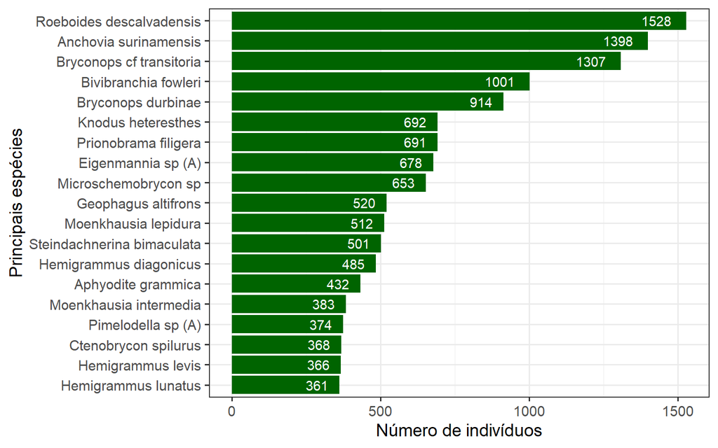

```r
# Gráfico

ggplot(esp, aes(x = reorder(species, n), y = n)) +
  # gráfico de barra
 geom_bar(stat = "identity", fill = "darkgreen") +
  # Inverte os eixos
 coord_flip() +
  # adciona rótulos nas barras
 geom_text(
   aes(label = n),
   color = "white",
   vjust = 0.5,
   hjust = 1.5
 ) +
  # Renomeia os eixos
 labs(x = "Principais espécies", y = "Número de indivíduos") +
  # tema do gráfico
 theme_bw(base_size = 14)
```

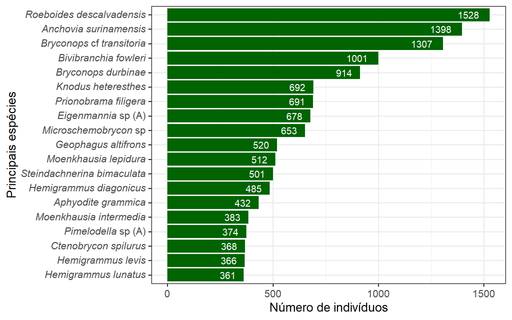

```r
 #------- Para deixar itálico------------#
 # Primeiro adiciona <i> para todas
 esp$esp2 <- paste0("<i>", esp$species, "</i>")

 # Separa sp
 esp$esp2<- sub(" sp</i>", "</i> sp",  esp$esp2)

 # Separação manual
 esp$esp2[3] <-"<i>Bryconops</i> cf <i>transitoria</i>"
 esp$esp2[8] <- "<i>Eigenmannia</i> sp (A)"
 esp$esp2[16] <- "<i>Pimelodella</i> sp (A)"

 # Gráfico
 ggplot(esp, aes(x = reorder(esp2, n), y = n)) +
   geom_bar(stat = "identity", fill = "darkgreen") +
   coord_flip() +
   geom_text(
     aes(label = n),
     color = "white",
     vjust = 0.5,
     hjust = 1.5
   ) +
   labs(x = "Principais espécies", y = "Número de indivíduos") +
   theme_bw(base_size = 14) +
   theme(axis.text.y = element_markdown())
```

```r
# Exercicio

 # ggplot(esp, aes(x = reorder(species, n), y = n)) +
 #   geom_bar(stat = "identity", fill = "_____________") +
 #   coord_flip() +
 #   geom_text(aes(label = n),
 #     color = "________",
 #     vjust = 0.5,
 #     hjust = 1.5) +
 #   labs(title = "____________", x = "Principais espécies",
 #     y = "Número de indivíduos") +
 #   theme___________()
```

### **Abundância**

```r
# Abundancia-------------------------------
abundancia <-  dados_ictio |>
  group_by(river_system,habitat ,date) |>
  count()
```

#### **Gráfico de abundancia**

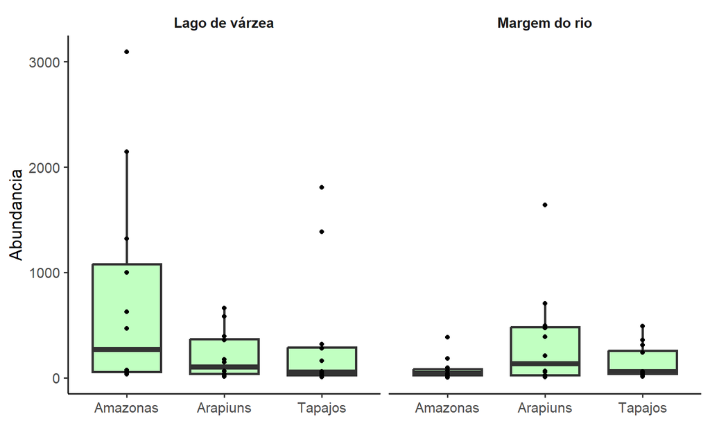

```r
# Boxplot

# Traduzir os fatores
abundancia$habitat <- as.factor(abundancia$habitat )
levels(abundancia$habitat) <- c("Lago de várzea", "Margem do rio")

plot_abundancia <- ggplot(abundancia, aes(x= river_system, y = n))+
  # Geometria boxplot
  geom_boxplot(width = .7, fill = "darkseagreen1",
    show.legend = FALSE, size = 1)+
  # geometria de ponto
  geom_point(show.legend = FALSE)+
  # tema do gráfico
  theme_classic(base_size = 14)+
  # Divisão do dataset
  facet_wrap( ~ habitat)+
  # tema do gráfico
  theme(strip.text = element_text(face = "bold"))+
  labs(x = "", y = "Abundancia")+
  theme(strip.background = element_blank())

plot_abundancia
```

#### **Riqueza de espécies**

```r
# Riqueza de espécies -----------------------------------

riqueza <-  dados_ictio |>
  group_by(river_system,habitat ,date) |>
  summarise(riq = n_distinct(species))
```

#### **Gráfico de riquza**

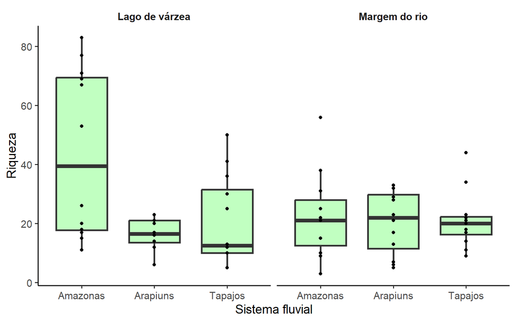

```r
# Boxplot

riqueza$habitat <- as.factor(riqueza$habitat)
levels(riqueza$habitat) <- c("Lago de várzea", "Margem do rio")

plot_riqueza <- ggplot(riqueza, aes(x= river_system, y = riq))+
  geom_boxplot(width = .7, fill = "darkseagreen1",
    show.legend = FALSE, size = 1)+
  geom_point(show.legend = FALSE)+
  theme_classic(base_size = 14)+
  facet_wrap( ~ habitat)+
  theme(strip.text = element_text(face = "bold"))+
  labs(x = "Sistema fluvial", y = "Riqueza")+
  theme(strip.background = element_blank())

plot_riqueza
```

##### **juntando os gráficos**

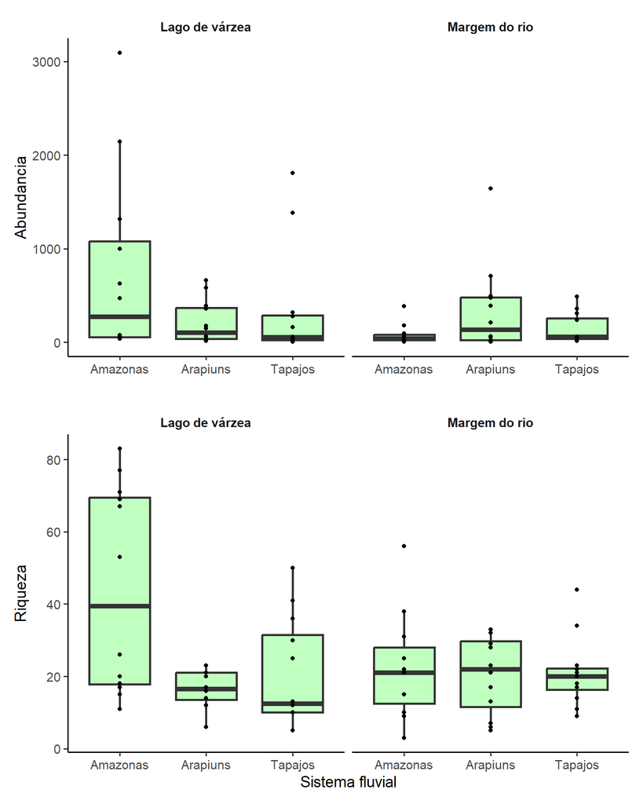

```r
# juntando os gráficos
plot_abundancia / plot_riqueza
```

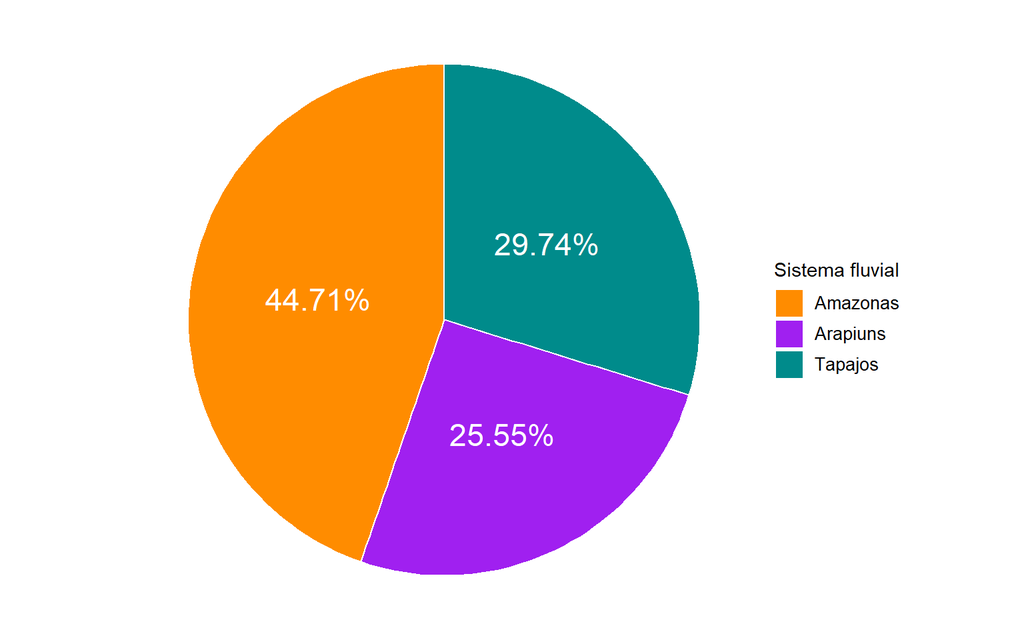

```r
# Riqueza de espécies por sistema

riqueza <- dados_ictio |>
  group_by(river_system) |>
  summarise(riq = n_distinct(species)) |>
  ungroup()

# Porcentagem
riqueza_prop <- riqueza %>%
  dplyr::mutate(prop = round(riq/sum(riq), 4)*100)


# Gráfico de pizza
ggplot(data = riqueza_prop, aes(x = "", y = prop,
  fill = river_system)) +
  geom_bar(stat = "identity", color = "white") +
  geom_text(aes(label = paste0(prop, "%")), color = "white",
    position = position_stack(vjust = .5), size = 6) +
  scale_fill_manual(values = c("darkorange", "purple", "cyan4")) +
  coord_polar(theta = "y", start = 0) +
  theme_void() +
  labs(fill = "Sistema fluvial")+
  theme(legend.text = element_markdown(color = "black",
    size = 10))
```

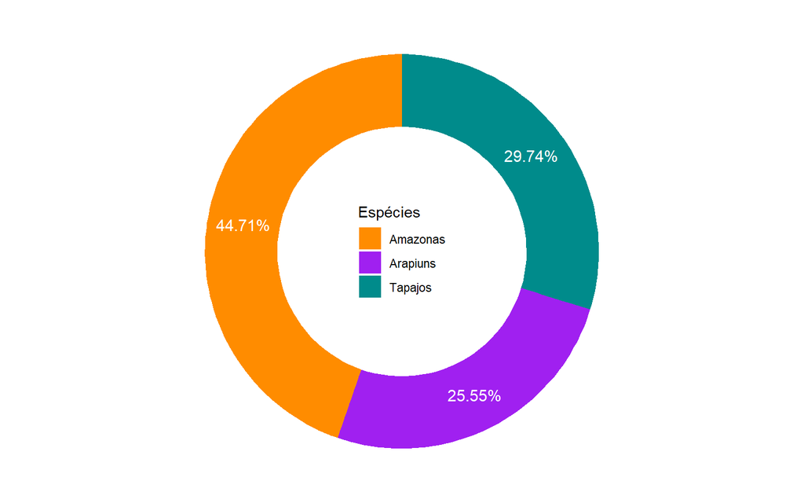

```r
# Gráfico de donut
ggplot(data = riqueza_prop, aes(x = 2, y = prop, fill = river_system)) +
  geom_bar(stat = "identity") +
  geom_text(aes(label = paste0(prop, "%")), color = "white",
    position = position_stack(vjust = .5), size = 4) +
  scale_fill_manual(values = c("darkorange", "purple", "cyan4")) +
  coord_polar(theta = "y", start = 0) +
  xlim(0, 2.5) +
  theme_void() +
  theme(legend.position = c(.5, .5)) +
  labs( fill = "Espécies")
```

### **Variáveis limnológicas**

```r
glimpse(dados_ictio[,c(5, 7:13)])
```

```
## Rows: 22,398
## Columns: 8
## $ river_system <chr> "Amazonas", "Amazonas", "Amazonas", "Amazonas", "Amazonas…
## $ date         <dttm> 2014-11-26, 2014-11-26, 2014-11-26, 2014-11-26, 2014-11-…
## $ habitat      <chr> "Floodplain lake", "Floodplain lake", "Floodplain lake", …
## $ temp         <dbl> 30.1, 30.1, 30.1, 30.1, 30.1, 30.1, 30.1, 30.1, 30.1, 30.…
## $ ph           <dbl> 6.94, 6.94, 6.94, 6.94, 6.94, 6.94, 6.94, 6.94, 6.94, 6.9…
## $ do           <dbl> 4.7, 4.7, 4.7, 4.7, 4.7, 4.7, 4.7, 4.7, 4.7, 4.7, 4.7, 4.…
## $ cd           <dbl> 78.1, 78.1, 78.1, 78.1, 78.1, 78.1, 78.1, 78.1, 78.1, 78.…
## $ tb           <dbl> 169, 169, 169, 169, 169, 169, 169, 169, 169, 169, 169, 16…
```

```r
dados_limno <-  dados_ictio[,c(4,5, 7:13)]
```

#### **Temperatura**

Verificando a relação com dados das espécies

```r
# Temperatura
dados_temp <- dados_limno |>
  group_by(river_system, habitat, temp) |>
  select(species) |>
  count()
dados_temp
```

```
## # A tibble: 77 × 4
## # Groups:   river_system, habitat, temp [77]
##    river_system habitat          temp     n
##    <chr>        <chr>           <dbl> <int>
##  1 Amazonas     Floodplain lake  28.7    53
##  2 Amazonas     Floodplain lake  28.8   469
##  3 Amazonas     Floodplain lake  29       4
##  4 Amazonas     Floodplain lake  29.2   628
##  5 Amazonas     Floodplain lake  29.4    19
##  6 Amazonas     Floodplain lake  29.8    91
##  7 Amazonas     Floodplain lake  30      19
##  8 Amazonas     Floodplain lake  30.1  2144
##  9 Amazonas     Floodplain lake  30.2  3092
## 10 Amazonas     Floodplain lake  30.4  1356
## # ℹ 67 more rows
```

#### **Gráfico**

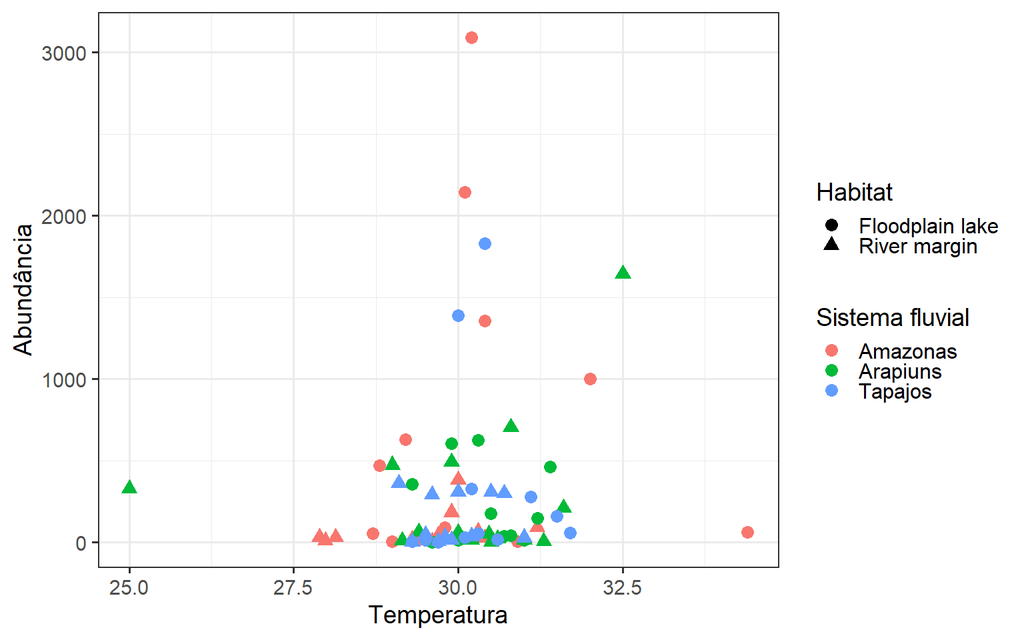

```r
ggplot(dados_temp, aes(x = temp, y = n))+
  geom_point(aes(col = river_system, shape = habitat), size = 3)+
  theme_bw(base_size = 14)+
  labs(x = "Temperatura", y = "Abundância", col = "Sistema fluvial ", shape = "Habitat")+
  # "right", "left", "bottom", "top"
  theme(legend.position = "right",
    legend.key.height = unit(.3, 'cm'),
    legend.text = element_text(size=12),
    legend.background  = element_blank())
```

**Da para ver o comportamento dos dados por um histograma**

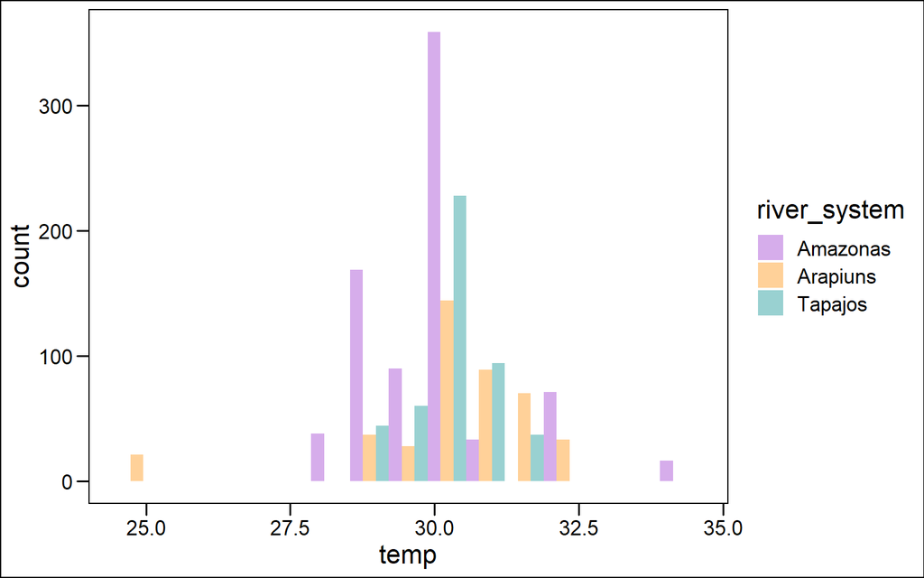

```r
dados_ictio |>
  group_by(river_system, species, temp) |>
  count(species) |>
  ggplot(aes(x = temp,  fill = river_system))+
  geom_histogram(alpha = .4, position = "dodge",bins = 15)+
  scale_fill_manual(values = c("darkorchid","darkorange", "cyan4"))+
  theme_base()
```

**Ou por um gráfico de densidade**

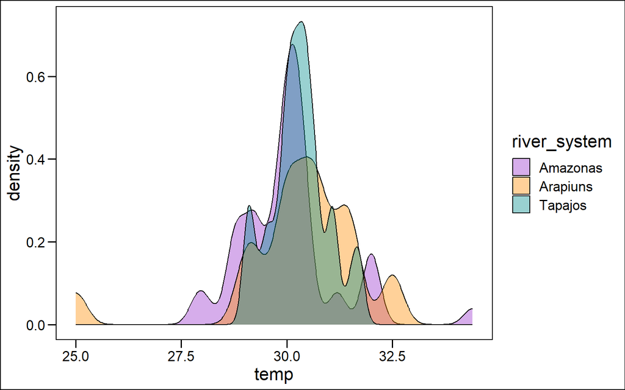

```r
dados_ictio |>
  group_by(river_system, species, temp) |>
  count(species) |>
  ggplot(aes(x = temp,  fill = river_system))+
  geom_density(alpha = .4)+
  scale_fill_manual(values = c("darkorchid","darkorange", "cyan4"))+
  theme_base()
```

#### **Sumário estatístico**

```r
sumario_temp <-  dados_limno |>
  group_by(river_system, habitat) |>
  select(temp) |>
  get_summary_stats(type = "common")
sumario_temp
```

```
## # A tibble: 6 × 12
##   river_system habitat variable     n   min   max median   iqr  mean    sd    se
##   <chr>        <chr>   <fct>    <dbl> <dbl> <dbl>  <dbl> <dbl> <dbl> <dbl> <dbl>
## 1 Amazonas     Floodp… temp      8965  28.7  34.4   30.2   0.3  30.3 0.821 0.009
## 2 Amazonas     River … temp       911  27.9  31.2   30     0.1  29.9 0.7   0.023
## 3 Arapiuns     Floodp… temp      2519  29.3  31.4   30.3   0.9  30.3 0.679 0.014
## 4 Arapiuns     River … temp      4098  25    32.5   30.8   2.6  30.7 2.10  0.033
## 5 Tapajos      Floodp… temp      4166  29.3  31.7   30.4   0.4  30.4 0.402 0.006
## 6 Tapajos      River … temp      1739  29.1  31     30     0.9  30.0 0.59  0.014
## # ℹ 1 more variable: ci <dbl>
```

#### **Visualizando o resultado**

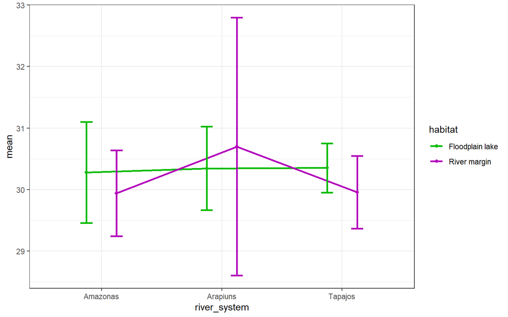

```r
plot_temp <-  ggplot(sumario_temp,
  aes(x = river_system,y = mean,col = habitat,group = habitat)) +
  geom_line(linewidth = 1, position = position_dodge(.5)) +
  geom_point(position = position_dodge(0.5)) +
  geom_errorbar(aes(ymin = mean - sd, ymax = mean + sd),
    linewidth = 1,width = .2, position = position_dodge(0.5))+
  theme_bw()+
  scale_color_manual(values = c("#08bb00",  "#b300bb"))
plot_temp
```

#### **pH**

```r
# Sumário estatístico de pH
sumario_ph <-  dados_limno |>
  group_by(river_system, habitat) |>
  select(ph) |>
  get_summary_stats(type = "common")
```

#### **Visualizando o reultado**

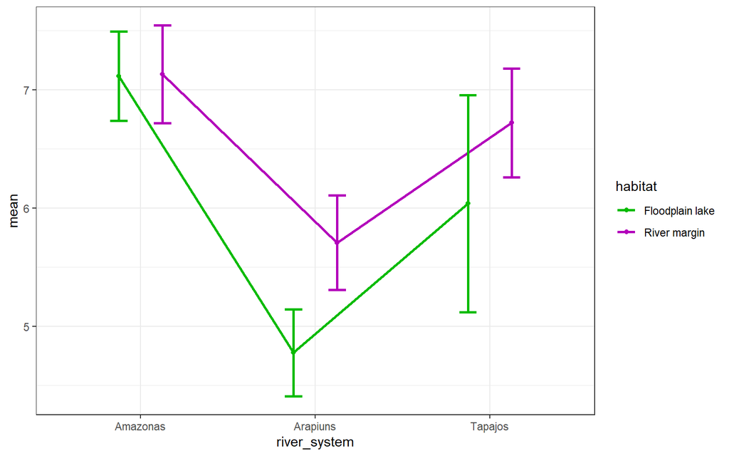

```r
# Visualizando
plot_ph <-  ggplot(sumario_ph,
  aes(
    x = river_system,
    y = mean,
    col = habitat,
    group = habitat
  )) +
  geom_line(linewidth = 1, position = position_dodge(.5)) +
  geom_point(position = position_dodge(0.5)) +
  geom_errorbar(
    aes(ymin = mean - sd, ymax = mean + sd),
    linewidth = 1,
    width = .2,
    position = position_dodge(0.5)
  ) +
  theme_bw() +
  scale_color_manual(values = c("#08bb00",  "#b300bb"))

plot_ph
```

#### **Do**

```r
# Sumário estatístico de Do
sumario_do <-  dados_limno |>
  group_by(river_system, habitat) |>
  select(do) |>
  get_summary_stats(type = "common")
```

#### **Visualizando o resultado**

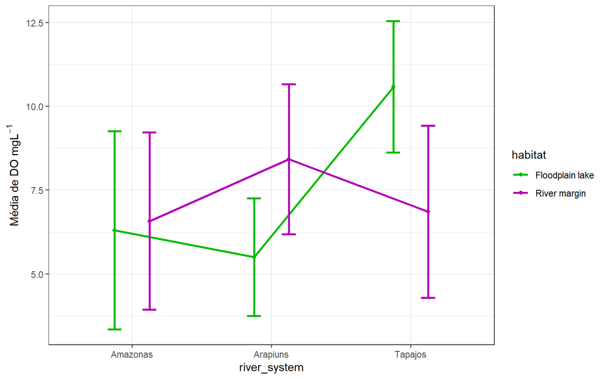

```r
# Visualizando
plot_do <-  ggplot(sumario_do, aes( x = river_system,
                                    y = mean, col = habitat,
                                    group = habitat)) +
  geom_line(linewidth = 1, position = position_dodge(.5)) +
  geom_point(position = position_dodge(0.5)) +
  geom_errorbar(
    aes(ymin = mean - sd, ymax = mean + sd),
    linewidth = 1,
    width = .2,
    position = position_dodge(0.5)
  ) +
  theme_bw() +
  labs(y = bquote("Média de DO mgL"^-1)) +
  scale_color_manual(values = c("#08bb00",  "#b300bb"))

plot_do
```

Os resultados podem ser apresentados em um gráfico de barras com erros

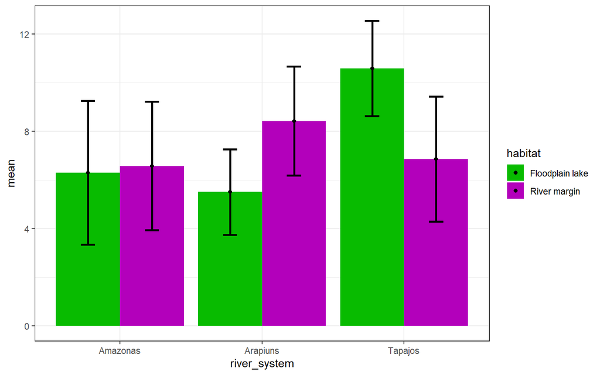

```r
# Gráfico de barras com erros
ggplot(sumario_do, aes( x = river_system,
                        y = mean, fill = habitat,
                        group = habitat)) +
#  geom_line(linewidth = 1, position = position_dodge(.5)) +
  geom_bar(stat="identity", position=position_dodge())+
  geom_errorbar(
    aes(ymin = mean - sd, ymax = mean + sd),
    linewidth = 1,
    width = .2,
    position = position_dodge(0.9)
  )+
  geom_point(position = position_dodge(0.9)) +
  theme_bw() +
  scale_fill_manual(values = c("#08bb00",   "#b300bb"))
```

#### **Juntando gráficos**

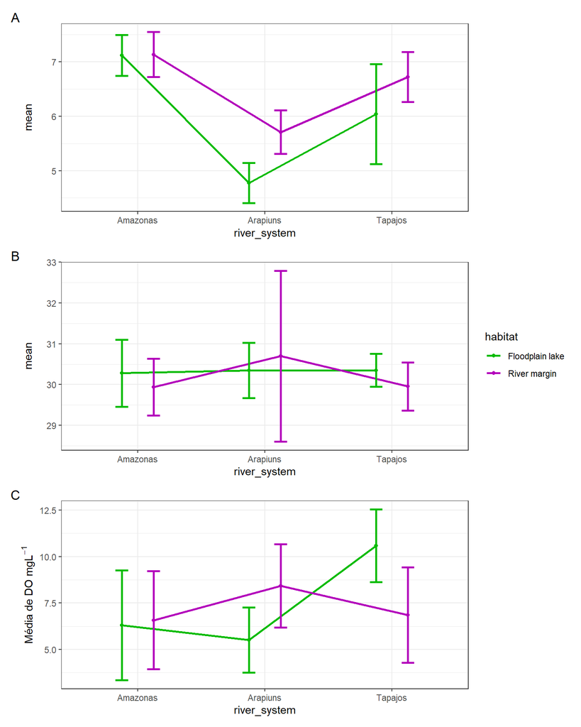

```r
plot_ph/ plot_temp / plot_do + plot_layout(guides = "collect")+
  plot_annotation(tag_levels = "A")
```

```r
# Salvando o gráfico
ggsave('resultados/plot.jpeg', width = 15, height = 10, units = "cm", dpi = 300)
```

### **Testes estatisticos**

#### **Teste t**

**Pergunta:** Será se o comprimento padrão da espécie é diferente por período?

```r
# Teste t -------------------------------------------------------

dados_peixes <- read_csv2('dados/teste_t.csv')
```

```
## ℹ Using "','" as decimal and "'.'" as grouping mark. Use `read_delim()` for more control.
```

##### Checando a normalidade

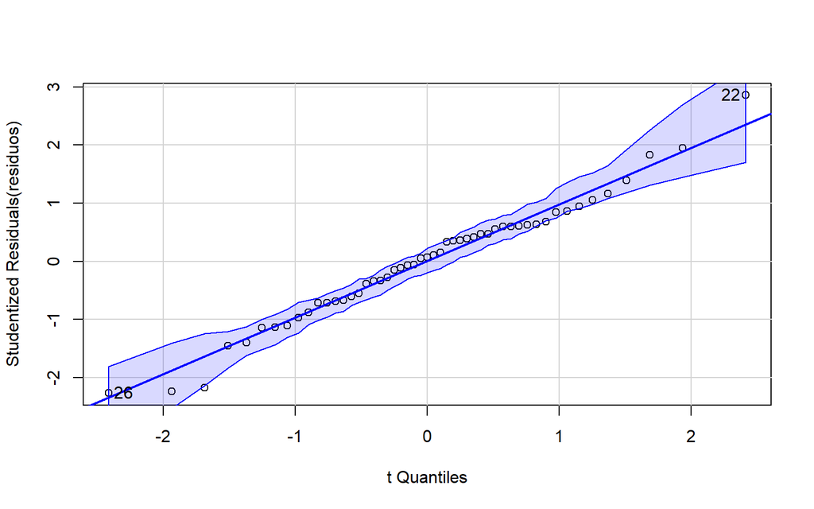

```
## [1] 22 26
```

```r
# Normalidade

# Teste de normalidade
residuos <- lm(cp ~ as.factor(periodo), data = dados_peixes)

# visualização dos resíduos
qqPlot(residuos)
```

```r
## Teste de Shapiro-Wilk
residuos_modelo <- residuals(residuos)
shapiro.test(residuos_modelo)
```

```
##
##  Shapiro-Wilk normality test
##
## data:  residuos_modelo
## W = 0.98307, p-value = 0.6746
```

##### Homocedasticidade

```r
# Homocedasticidade

## Teste de homogeneidade de variância
leveneTest(cp ~ as.factor(periodo), data = dados_peixes)
```

```
## Levene's Test for Homogeneity of Variance (center = median)
##       Df F value Pr(>F)
## group  1  1.1677 0.2852
##       49
```

##### Resultado do teste T

```r
# Teste T
t.test(cp ~ periodo, data = dados_peixes, var.equal = TRUE)
```

```
##
##  Two Sample t-test
##
## data:  cp by periodo
## t = 4.1524, df = 49, p-value = 0.000131
## alternative hypothesis: true difference in means between group Cheia and group Seca is not equal to 0
## 95 percent confidence interval:
##  0.2242132 0.6447619
## sample estimates:
## mean in group Cheia  mean in group Seca
##            103.6954            103.2609
```

```r
# ou
dados_peixes |> t_test(cp ~ periodo,  var.equal = TRUE)
```

```
## # A tibble: 1 × 8
##   .y.   group1 group2    n1    n2 statistic    df        p
## * <chr> <chr>  <chr>  <int> <int>     <dbl> <dbl>    <dbl>
## 1 cp    Cheia  Seca      28    23      4.15    49 0.000131
```

##### Visualizando o resultado

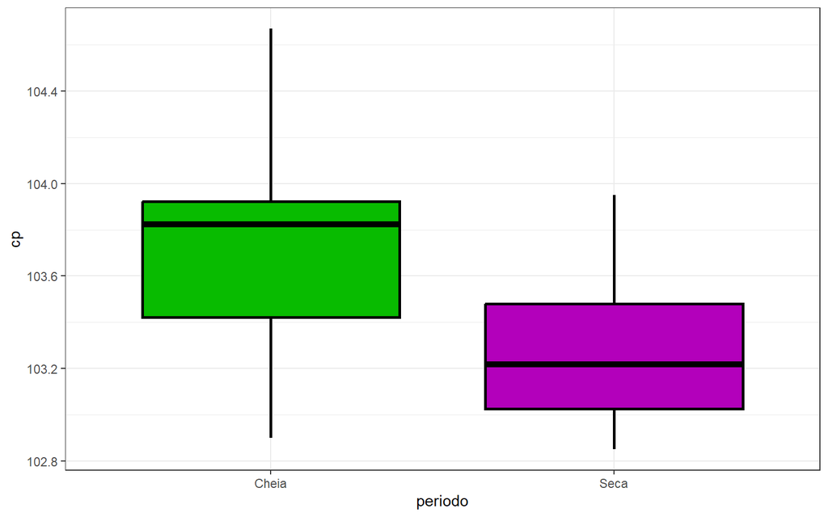

```r
ggplot(dados_peixes, aes(x = periodo, y = cp))+
  geom_boxplot(fill = c("#08bb00",  "#b300bb"), color = "black",
               linewidth = 1) +
  scale_color_manual(values = c("black", "black")) +
  theme_bw() +
  theme(legend.position = "none")
```

#### **Regressão**

**Pergunta:** A temperatura afeta no tamanho da espécie?

```r
# Regressão -----------------------------------------------------

regressao <- read_csv2('dados/regressao.csv')
```

```
## ℹ Using "','" as decimal and "'.'" as grouping mark. Use `read_delim()` for more control.
```

##### Modelo

```r
# modelo
```

##### Verificar as premissas

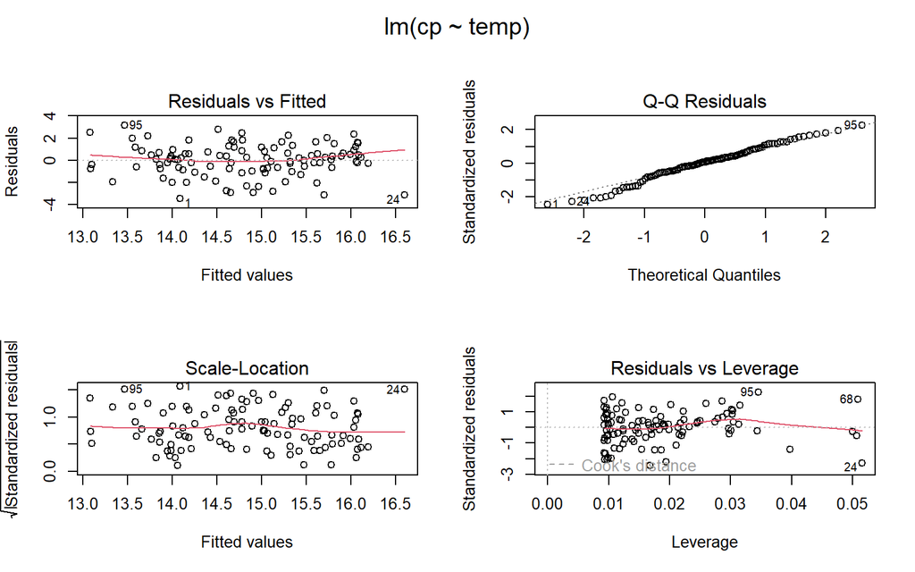

```r
modelo_regressao <- lm(cp ~ temp, data = regressao)
## Verificar as premissas do teste
par(mfrow = c(2, 2), oma = c(0, 0, 2, 0))
plot(modelo_regressao)
```

##### Normalidade

```r
## Teste de Shapiro-Wilk
residuos_modelo <- residuals(modelo_regressao)
shapiro.test(residuos_modelo)
```

```
##
##  Shapiro-Wilk normality test
##
## data:  residuos_modelo
## W = 0.98367, p-value = 0.2092
```

##### Resultados

```r
## Resultados usando a função anova
anova(modelo_regressao)
```

```
## Analysis of Variance Table
##
## Response: cp
##            Df  Sum Sq Mean Sq F value    Pr(>F)
## temp        1  73.677  73.677   36.25 2.533e-08 ***
## Residuals 106 215.443   2.032
## ---
## Signif. codes:  0 '***' 0.001 '**' 0.01 '*' 0.05 '.' 0.1 ' ' 1
```

```r
## Resultados usando a função summary
summary(modelo_regressao)
```

```
##
## Call:
## lm(formula = cp ~ temp, data = regressao)
##
## Residuals:
##     Min      1Q  Median      3Q     Max
## -3.4581 -0.7552  0.1034  0.8751  3.1815
##
## Coefficients:
##             Estimate Std. Error t value Pr(>|t|)
## (Intercept)  6.59948    1.37465   4.801 5.21e-06 ***
## temp         0.26707    0.04436   6.021 2.53e-08 ***
## ---
## Signif. codes:  0 '***' 0.001 '**' 0.01 '*' 0.05 '.' 0.1 ' ' 1
##
## Residual standard error: 1.426 on 106 degrees of freedom
## Multiple R-squared:  0.2548, Adjusted R-squared:  0.2478
## F-statistic: 36.25 on 1 and 106 DF,  p-value: 2.533e-08
```

##### Visualizando o resultado

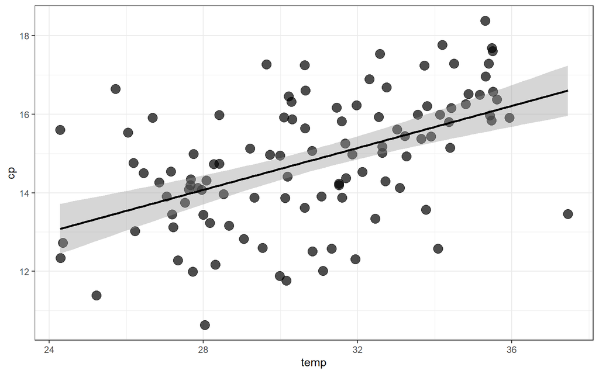

```r
ggplot(regressao, aes(x = temp, y = cp))+
  geom_point(size = 4, shape = 19, alpha = 0.7)+
  geom_smooth(method = "lm", se = TRUE, color = "black")+
  theme_bw()
```

#### **Anova**

**Pergunta:** A riqueza de espécie é diferente entre os períodos

```r
# Anova ---------------------------------------------------------


dados_anova <- read_csv2("dados/dados_anova.csv")
```

```
## ℹ Using "','" as decimal and "'.'" as grouping mark. Use `read_delim()` for more control.
```

##### Modelo

```r
modelo <- aov(riqueza ~ periodo, data = dados_anova)
```

##### Normalidade

```r
## Normalidade
shapiro.test(residuals(modelo))
```

```
##
##  Shapiro-Wilk normality test
##
## data:  residuals(modelo)
## W = 0.97289, p-value = 0.2016
```

##### Homogeneidade da variância

```r
## Homogeneidade da variância
bartlett.test(riqueza ~ periodo, data = dados_anova)
```

```
##
##  Bartlett test of homogeneity of variances
##
## data:  riqueza by periodo
## Bartlett's K-squared = 15.657, df = 3, p-value = 0.001333
```

```r
# ou
leveneTest(riqueza ~ as.factor(periodo), data = dados_anova)
```

```
## Levene's Test for Homogeneity of Variance (center = median)
##       Df F value   Pr(>F)
## group  3  4.3277 0.008183 **
##       56
## ---
## Signif. codes:  0 '***' 0.001 '**' 0.01 '*' 0.05 '.' 0.1 ' ' 1
```

**Quando a Homogeneidade é violada é feita a Anova de Welch**

```r
# Anova de Welch
oneway.test(riqueza ~ periodo, data = dados_anova)
```

```
##
##  One-way analysis of means (not assuming equal variances)
##
## data:  riqueza and periodo
## F = 72.755, num df = 3.000, denom df = 29.307, p-value = 1.099e-13
```

```r
# Resultado bonitinho
welch_anova_test(dados_anova, riqueza ~ periodo)
```

```
## # A tibble: 1 × 7
##   .y.         n statistic   DFn   DFd        p method
## * <chr>   <int>     <dbl> <dbl> <dbl>    <dbl> <chr>
## 1 riqueza    60      72.8     3  29.3 1.10e-13 Welch ANOVA
```

**Diferenças entre os períodos**

```r
## Diferenças entre os períodos
TukeyHSD(modelo)
```

```
##   Tukey multiple comparisons of means
##     95% family-wise confidence level
##
## Fit: aov(formula = riqueza ~ periodo, data = dados_anova)
##
## $periodo
##                        diff        lwr       upr     p adj
## Enchente-Cheia    -5.933333 -24.235434  12.36877 0.8260846
## Seca-Cheia        81.733333  63.431233 100.03543 0.0000000
## Vazante-Cheia     26.466667   8.164566  44.76877 0.0018098
## Seca-Enchente     87.666667  69.364566 105.96877 0.0000000
## Vazante-Enchente  32.400000  14.097900  50.70210 0.0001047
## Vazante-Seca     -55.266667 -73.568767 -36.96457 0.0000000
```

```r
# Resultado bonitinho
tukey_hsd(modelo)
```

```
## # A tibble: 6 × 9
##   term    group1   group2   null.value estimate conf.low conf.high    p.adj
## * <chr>   <chr>    <chr>         <dbl>    <dbl>    <dbl>     <dbl>    <dbl>
## 1 periodo Cheia    Enchente          0    -5.93   -24.2       12.4 8.26e- 1
## 2 periodo Cheia    Seca              0    81.7     63.4      100.  7.32e-12
## 3 periodo Cheia    Vazante           0    26.5      8.16      44.8 1.81e- 3
## 4 periodo Enchente Seca              0    87.7     69.4      106.  7.31e-12
## 5 periodo Enchente Vazante           0    32.4     14.1       50.7 1.05e- 4
## 6 periodo Seca     Vazante           0   -55.3    -73.6      -37.0 4.77e-10
## # ℹ 1 more variable: p.adj.signif <chr>
```

**Abordagem não paramétrica**

```r
# Não paramétrico
kruskal_test(dados_anova, riqueza ~ periodo)
```

```
## # A tibble: 1 × 6
##   .y.         n statistic    df             p method
## * <chr>   <int>     <dbl> <int>         <dbl> <chr>
## 1 riqueza    60      40.4     3 0.00000000878 Kruskal-Wallis
```

```r
dunn_test(dados_anova, riqueza ~ periodo)
```

```
## # A tibble: 6 × 9
##   .y.     group1   group2      n1    n2 statistic         p   p.adj p.adj.signif
## * <chr>   <chr>    <chr>    <int> <int>     <dbl>     <dbl>   <dbl> <chr>
## 1 riqueza Cheia    Enchente    15    15    -0.957   3.39e-1 3.39e-1 ns
## 2 riqueza Cheia    Seca        15    15     4.89    1.01e-6 5.07e-6 ****
## 3 riqueza Cheia    Vazante     15    15     2.15    3.12e-2 6.24e-2 ns
## 4 riqueza Enchente Seca        15    15     5.85    5.04e-9 3.02e-8 ****
## 5 riqueza Enchente Vazante     15    15     3.11    1.86e-3 7.45e-3 **
## 6 riqueza Seca     Vazante     15    15    -2.73    6.24e-3 1.87e-2 *
```

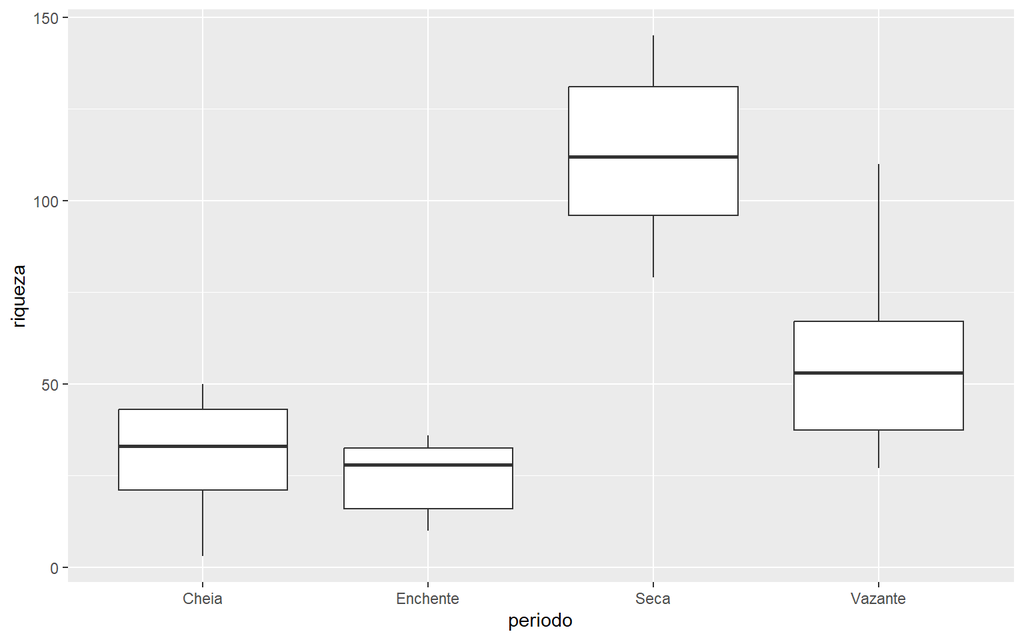

```r
ggplot(dados_anova, aes(x = periodo, y = riqueza))+
  geom_boxplot()
```